# scratchpad

```python
import sys
import pickle
sys.path.append("../tools/")

from feature_format import featureFormat, targetFeatureSplit
from tester import dump_classifier_and_data

import numpy as np
import pandas as pd

import matplotlib.pyplot as plt
%matplotlib inline

import warnings
warnings.filterwarnings('ignore')
```

```python
with open("final_project_dataset.pkl", "r") as data_file:
    data_dict = pickle.load(data_file)
df = pd.DataFrame.from_dict(data_dict, orient='index')
df = df.replace('NaN', np.nan)
```

## Understanding the Dataset

```python
# statistics about the data set
print 'Number of people:', df['poi'].count()
print 'Number of POIs:', df.loc[df.poi == True, 'poi'].count()
print 'Fraction of examples that are POIs:', \
    float(df.loc[df.poi == True, 'poi'].count()) / df['poi'].count()
print 'Number of features:', df.shape[1]
```

```
Number of people: 146
Number of POIs: 18
Fraction of examples that are POIs: 0.123287671233
Number of features: 21
```

```python
#The counts of NaNs in each column
print 'Missing data in each column'
df.isnull().sum()
```

```
Missing data in each column
```

```
salary                        51
to_messages                   60
deferral_payments            107
total_payments                21
exercised_stock_options       44
bonus                         64
restricted_stock              36
shared_receipt_with_poi       60
restricted_stock_deferred    128
total_stock_value             20
expenses                      51
loan_advances                142
from_messages                 60
other                         53
from_this_person_to_poi       60
poi                            0
director_fees                129
deferred_income               97
long_term_incentive           80
email_address                 35
from_poi_to_this_person       60
dtype: int64
```

Looking at the distribution of the missing data we can see that the counts for all the email features are the same. This suggests that one of the processes that is causing the missing data is lack of email data for certain persons.

This suggests the possibility of a new feature to me. It may be the case that persons involved in the fraud were able to encrypt or otherwise prevent their emails from coming into the hands of the courts. To tests this hypothesis I will create the feature and look at the counts of POI/non_POI.

```python
df['email_withheld'] = df.to_messages.isnull()
df.groupby(['email_withheld', 'poi'])['poi'].count()
```

```
email_withheld  poi
False           False    72
                True     14
True            False    56
                True      4
Name: poi, dtype: int64
```

From inspection this feature does not appear to be particularly informative however will include it in the model as it could be a useful feature for growing decision trees.

The financial features are less predictable in how the values are missing. One way of interpreting this data is that a NaN value is equivalent to a zero. For example if an employee did not receive a bonus then this value could be assigned NaN. This view is supported by the insider pay pdf document in how the totals are calculated. I decided to replace all the NaNs in the financial features with zero.

```python
financial_features = ['salary', 'deferral_payments', 'total_payments', 'loan_advances', 'bonus', 'restricted_stock_deferred', 'deferred_income', 'total_stock_value', 'expenses', 'exercised_stock_options', 'other', 'long_term_incentive', 'restricted_stock', 'director_fees']
email_features = ['to_messages', 'from_poi_to_this_person', 'from_messages', 'from_this_person_to_poi', 'shared_receipt_with_poi']
```

```python
df[financial_features] = df[financial_features].fillna(0)
```

As for the email features. Firstly I decided to drop the email address column as this is uninformative for a machine learning algorithm. Some possibilities for how to deal with the missing values are:

- Drop rows that contain missing values
- Impute the missing values with some function of the columns
- Develop two independent classifiers for the email and financial features and combining their outputs

If we drop the rows containing NaNs this will mean losing almost half of our training data which is not acceptable. Creating two classifiers could be an elegant solution but its implementation may be too complex for this project. Additionally a learner would be unable to learn interactions between financial and email features.

I decided to go with the imputation method using the median of the columns.

```python
df[email_features] = df[email_features].fillna(df[email_features].median())
```

## Identifying Outliers

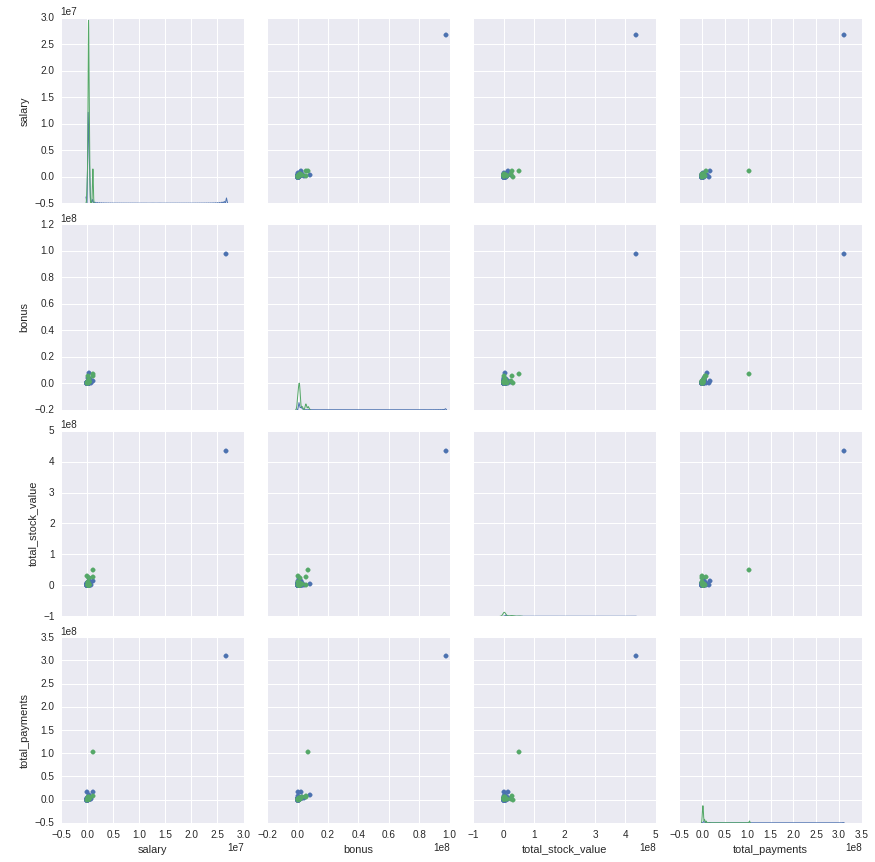

```python
import seaborn as sns
g = sns.PairGrid(df, vars=['salary','bonus','total_stock_value','total_payments'],
                hue='poi')
g.map_lower(plt.scatter)
g.map_upper(plt.scatter)
g.map_diag(sns.kdeplot, lw=1)
```

One particular points stands out in all of the scatter plots as being far greater than the others. It is also interesting to note that this point is not a POI. This point will be investigated further.

```python
df[df.salary > 2.5e7]
```

|  | salary | to_messages | deferral_payments | total_payments | exercised_stock_options | bonus | restricted_stock | shared_receipt_with_poi | restricted_stock_deferred | total_stock_value | ... | from_messages | other | from_this_person_to_poi | poi | director_fees | deferred_income | long_term_incentive | email_address | from_poi_to_this_person | email_withheld |
| --- | --- | --- | --- | --- | --- | --- | --- | --- | --- | --- | --- | --- | --- | --- | --- | --- | --- | --- | --- | --- | --- |
| TOTAL | 26704229 | 1211 | 32083396 | 309886585 | 311764000 | 97343619 | 130322299 | 740.5 | -7576788 | 434509511 | ... | 41 | 42667589 | 8 | False | 1398517 | -27992891 | 48521928 | NaN | 35 | True |

1 rows × 22 columns

On closer inspection it is revealed that this point is in fact a 'TOTAL' of all the other columns. This row was likely created during the data wrangling process and accidentically propagated through to this stage. As it does not represent an employee this rows should definitely be removed.

```python
df = df.drop('TOTAL')
```

I also decided to investigate some of the email features to see if any outliers existed here. Particularly the to_messages and from_messages features.

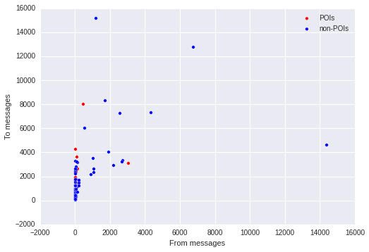

```python
pois = df[df.poi]
plt.scatter(pois.from_messages, pois.to_messages, c='red');
non_pois = df[~df.poi]
plt.scatter(non_pois.from_messages, non_pois.to_messages, c='blue');

plt.xlabel('From messages')
plt.ylabel('To messages')
plt.legend(['POIs', 'non-POIs'])
```

This plot does appear to contain some outiers. These are persons who send or receive far more emails than the average user. The point on the far right in particular sent over 14000 emails, the next closest being less then half of that. The three points that lie outside the main cluster of points are identified and examined in the code below.

|  | salary | to_messages | deferral_payments | total_payments | exercised_stock_options | bonus | restricted_stock | shared_receipt_with_poi | restricted_stock_deferred | total_stock_value | ... | from_messages | other | from_this_person_to_poi | poi | director_fees | deferred_income | long_term_incentive | email_address | from_poi_to_this_person | email_withheld |
| --- | --- | --- | --- | --- | --- | --- | --- | --- | --- | --- | --- | --- | --- | --- | --- | --- | --- | --- | --- | --- | --- |
| KAMINSKI WINCENTY J | 275101 | 4607 | 0 | 1086821 | 850010 | 400000 | 126027 | 583 | 0 | 976037 | ... | 14368 | 4669 | 171 | False | 0 | 0 | 323466 | vince.kaminski@enron.com | 41 | False |
| KEAN STEVEN J | 404338 | 12754 | 0 | 1747522 | 2022048 | 1000000 | 4131594 | 3639 | 0 | 6153642 | ... | 6759 | 1231 | 387 | False | 0 | 0 | 300000 | steven.kean@enron.com | 140 | False |
| SHAPIRO RICHARD S | 269076 | 15149 | 0 | 1057548 | 607837 | 650000 | 379164 | 4527 | 0 | 987001 | ... | 1215 | 705 | 65 | False | 0 | 0 | 0 | richard.shapiro@enron.com | 74 | False |

3 rows × 22 columns

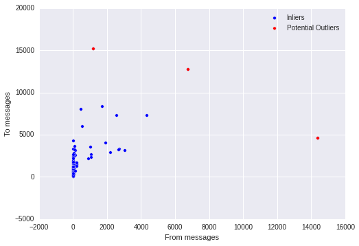

```python
# extract the outlier points
outliers = df[np.logical_or(df.from_messages > 6000, df.to_messages > 10000)]

#plot them in red with the originals
plt.scatter(df.from_messages, df.to_messages, c='blue');
plt.scatter(outliers.from_messages, outliers.to_messages, c='red')
plt.xlabel('From messages')
plt.ylabel('To messages')
plt.legend(['Inliers', 'Potential Outliers'])

#display in the notebook
outliers
```

There does not appear to be anything strange about these points other than their sent/received emails being way above average. Also as the counts of emails were generated automatically from a script it is unlikely these values are due to an error. These points are not capturing the general trend of email usage but are instead most likely people in some special job position that requires them to do a lot of communication by email. Additionally none of these points are POI so the large number of emails is not indicitive of this. For these reasons I deemed it unlikely that these points would be useful to improve the generalization of a machine learning algorithm and decided to remove them.

```python
# remove the outlier candidates from the data set
df = df[df.from_messages < 6000]
df = df[df.to_messages < 10000]
```

## First attempty at Classifying the Dataset

```python
# Convert the data frame into a sklearn compatible data set
X = df.drop(['poi', 'email_address'], axis=1)
y = df.poi
```

```python
# firstly get an estimate of the kind of accuracies we can expect with the unprocessed features
from sklearn.ensemble import RandomForestClassifier, AdaBoostClassifier
from sklearn.naive_bayes import GaussianNB

from sklearn.cross_validation import cross_val_score, StratifiedKFold, StratifiedShuffleSplit
from sklearn.metrics import classification_report

from sklearn.metrics import make_scorer, accuracy_score, precision_score, recall_score, f1_score

def assess_classifier(clf, X, y):


    cv = StratifiedShuffleSplit(y, 100, random_state=42)

    print 'accuracy', cross_val_score(clf, X, y, cv=cv).mean()
    print 'precision', cross_val_score(clf, X, y, scoring=make_scorer(precision_score), cv=cv).mean()
    print 'recall', cross_val_score(clf, X, y, scoring=make_scorer(recall_score), cv=cv).mean()


def assess_features(X, y):
    clf = RandomForestClassifier(random_state=42)
    assess_classifier(clf, X, y)

    print

    clf = GaussianNB()
    assess_classifier(clf, X, y)
    print

    clf = AdaBoostClassifier(random_state=42)
    assess_classifier(clf, X, y)
```

```python
assess_features(X, y)
```

```
accuracy 0.867333333333
precision 0.238333333333
recall 0.16

accuracy 0.735333333333
precision 0.233980519481
recall 0.32

accuracy 0.834666666667
precision 0.268166666667
recall 0.265
```

Straight out of the box the random forest is doing much better in terms of accuracy. Looking at recall however it is a totally different story. To pass this project we require >0.3 for both precison and recall so clearly some work is needed here.

## Feature Engineering

Based on the lessons I decided to implement the features fraction*_of_messages*[to|from]_poi and see how these influence classification performance.

```python
X_new = X.copy()
X_new['fracion_of_messages_to_poi'] = X.from_this_person_to_poi / X.from_messages
X_new['fracion_of_messages_from_poi'] = X.from_poi_to_this_person / X.to_messages
X_new = X_new.drop('from_this_person_to_poi', axis=1)
X_new = X_new.drop('from_poi_to_this_person', axis=1)
```

```python
assess_features(X_new, y)
```

```
accuracy 0.866666666667
precision 0.215
recall 0.16

accuracy 0.734666666667
precision 0.233980519481
recall 0.32

accuracy 0.861333333333
precision 0.452333333333
recall 0.41
```

## Feature Selection

It is thought that many of the features provided are redundant and the algorithms would perform better with them removed. The random forest is able to provide an estimate of feature importance directly so we will begin by looking at that

```python
# http://stackoverflow.com/questions/16010869/python-plot-a-bar-using-matplotlib-using-a-dictionary

import operator, pprint, collections

clf = AdaBoostClassifier(random_state=42)

def plot_feature_importances(clf, X, y):
    clf.fit(X, y)
    importances = sorted(zip(X.columns, clf.feature_importances_), key=operator.itemgetter(1))[::-1]
    importances = collections.OrderedDict(importances)
    plt.bar(range(len(importances)), importances.values(), align='center')
    plt.xticks(range(len(importances)), importances.keys(), rotation='vertical')
    plt.title('Feature Importances')
    plt.ylabel('Importance')
    plt.show()
    return importances
```

```
Random Forest Feature Importances
```

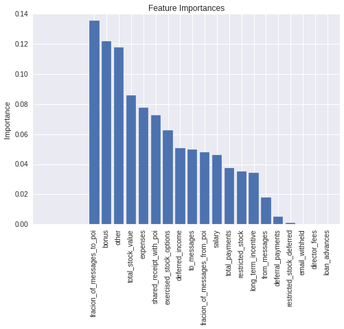

```
AdaBoost Feature Importances
```

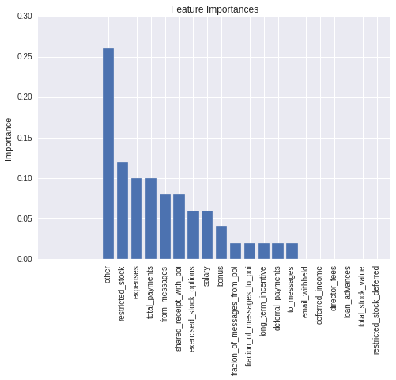

```python
print 'Random Forest Feature Importances'
rf_importances = plot_feature_importances(RandomForestClassifier(), X_new, y)
print 'AdaBoost Feature Importances'
ada_importances = plot_feature_importances(AdaBoostClassifier(), X_new, y)
```

This plot gives us some very useful information. The email_withheld feature we created is extremely uninformative and should be dropped. It seems safe to say that the lowest 6 features could also be dropped.

```python
X_new_selected = X_new.drop(ada_importances.keys()[-6:], axis = 1)
X_new_selected.columns
```

```
Index([u'salary', u'to_messages', u'deferral_payments', u'total_payments',
       u'exercised_stock_options', u'bonus', u'restricted_stock',
       u'shared_receipt_with_poi', u'expenses', u'from_messages', u'other',
       u'long_term_incentive', u'fracion_of_messages_to_poi',
       u'fracion_of_messages_from_poi'],
      dtype='object')
```

```python
assess_features(X_new_selected, y)
```

```
accuracy 0.869333333333
precision 0.21
recall 0.125

accuracy 0.822
precision 0.183333333333
recall 0.175

accuracy 0.865333333333
precision 0.436166666667
recall 0.385
```

For all the classifiers considered features scaling is not required

## Parameter tuning for RF and AdaBoost

Due to the consistent poor performance of the naive bayes classifier despite the lack of parameters I decided to abandon it for the remainder of the analysis.

The question is what metric to maximize? As the classifier we submit must have a good result for both precision and recall it makes sense to optimize for these. The f1-score is defined as a combination of the precision and recall so I decided to use this as the metric to optimze parameters for.

```python
from sklearn.grid_search import GridSearchCV
from sklearn.tree import DecisionTreeClassifier

n_features = X_new_selected.shape[1]
grid = {
    'criterion':('gini', 'entropy'),
    'min_samples_leaf':range(1, 50, 5),
    'max_depth': range(1, 10)
}

search = GridSearchCV(RandomForestClassifier(random_state=42),
                      grid, make_scorer(f1_score), cv=StratifiedKFold(y), n_jobs=-1)
search.fit(X_new_selected, y)
print search.best_score_
print search.best_params_
```

```
0.260060362173
{'criterion': 'entropy', 'max_depth': 6, 'min_samples_leaf': 1}
```

```python
assess_classifier(search.best_estimator_, X_new_selected, y)
```

```
accuracy 0.876666666667
precision 0.3375
recall 0.195
```

In scikit learn documentation it suggests:

"The main parameters to tune to obtain good results are n_estimators and the complexity of the base estimators (e.g., its depth max_depth or minimum required number of samples at a leaf min_samples_leaf in case of decision trees)."

so I decided to grid search over these parameters.

```python
grid = {
    'base_estimator__criterion': ('gini', 'entropy'),
    'base_estimator__min_samples_leaf':range(1, 50, 5),
    'base_estimator__max_depth': range(1, 10),
    'n_estimators': range(1,10)
}

search = GridSearchCV(AdaBoostClassifier(DecisionTreeClassifier(random_state=42), random_state=42),
                      grid, make_scorer(f1_score), cv=StratifiedKFold(y), n_jobs=-1)
search.fit(X_new_selected, y)
print search.best_score_
print search.best_params_
```

```
0.555164319249
{'n_estimators': 4, 'base_estimator__criterion': 'gini', 'base_estimator__max_depth': 3, 'base_estimator__min_samples_leaf': 11}
```

```python
assess_classifier(search.best_estimator_, X_new_selected, y)
```

```
accuracy 0.854666666667
precision 0.369166666667
recall 0.305
```

Finally I wanted to see if I could get away with using less base classifiers in the boosting algorithm. If so this could make the whole algorithm run faster at no cost. To assess this I used a validation curve over the number of classifiers.

```python
#http://scikit-learn.org/stable/auto_examples/model_selection/plot_validation_curve.html

from sklearn.learning_curve import validation_curve
def plot_validation_curve(clf, X, y, param, param_range):

    train_scores, test_scores = validation_curve(
        clf, X, y, param_name=param, param_range=param_range,
        cv=StratifiedKFold(y), scoring=make_scorer(f1_score), n_jobs=1)
    train_scores_mean = np.mean(train_scores, axis=1)
    train_scores_std = np.std(train_scores, axis=1)
    test_scores_mean = np.mean(test_scores, axis=1)
    test_scores_std = np.std(test_scores, axis=1)

    plt.ylabel("Score")
    plt.xlabel(param)
    plt.ylim(0.0, 1.1)
    plt.semilogx(param_range, train_scores_mean, label="Training score", color="r")
    plt.fill_between(param_range, train_scores_mean - train_scores_std,
                     train_scores_mean + train_scores_std, alpha=0.2, color="r")
    plt.semilogx(param_range, test_scores_mean, label="Cross-validation score",
                 color="g")
    plt.fill_between(param_range, test_scores_mean - test_scores_std,
                     test_scores_mean + test_scores_std, alpha=0.2, color="g")
    plt.legend(loc="best")
    plt.show()
```

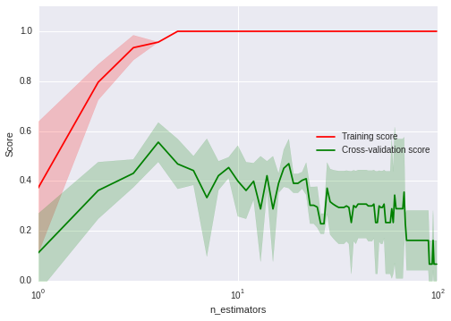

```python
plot_validation_curve(search.best_estimator_, X_new_selected, y, 'n_estimators', range(1,100,1))
```

From this plot it suggests that reducing the number of estimators below its current value is likely to reslt in a large decrease in f1 score so I chose to leave it at the optimized value.